# Assigment 3 - Social Network Analysis!

Paolo Rivas

10/21/2020

# Assignment 3 - Social Network Analysis

## Part I

Start by installing the “igraph” package. Once you have installed igraph, load the package.

Now upload the data file “comment-data.csv” as a data frame called “D1”. Each row represents a comment from one student to another so the first line shows that student “28” commented on the comment of student “21”. It also shows the gender of both students and the students’ main elective field of study (“major”").

```r
D1 <- read.csv("comment-data.csv", header = TRUE)
```

Before you proceed, you will need to change the data type of the student id variable. Since it is a number R will automatically think it is an integer and code it as such (look at the list of variables by clicking on the data frame arrow in the Data pane. Here you will see the letters “int”" next to the stid variable, that stands for integer). However, in this case we are treating the variable as a category, there is no numeric meaning in the variable. So we need to change the format to be a category, what R calls a “factor”. We can do this with the following code:

```r
D1$comment.to <- as.factor(D1$comment.to)
D1$comment.from <- as.factor(D1$comment.from)
```

igraph requires data to be in a particular structure. There are several structures that it can use but we will be using a combination of an “edge list” and a “vertex list” in this assignment. As you might imagine the edge list contains a list of all the relationships between students and any characteristics of those edges that we might be interested in. There are two essential variables in the edge list a “from” variable and a “to” variable that descibe the relationships between vertices. While the vertex list contains all the characteristics of those vertices, in our case gender and major.

So let’s convert our data into an edge list!

First we will isolate the variables that are of interest: comment.from and comment.to

```r
library(dplyr)
D2 <- select(D1, comment.to, comment.from) #select() chooses the columns
```

Since our data represnts every time a student makes a comment there are multiple rows when the same student comments more than once on another student’s video. We want to collapse these into a single row, with a variable that shows how many times a student-student pair appears.

```r
EDGE <- count(D2, comment.to, comment.from)

names(EDGE) <- c("to", "from", "count")
```

EDGE is your edge list. Now we need to make the vertex list, a list of all the students and their characteristics in our network. Because there are some students who only recieve comments and do not give any we will need to combine the comment.from and comment.to variables to produce a complete list.

```r
#First we will separate the commenters from our commentees
V.FROM <- select(D1, comment.from, from.gender, from.major)

#Now we will separate the commentees from our commenters

V.TO <- select(D1, comment.to, to.gender, to.major)

#Make sure that the from and to data frames have the same variables names
names(V.FROM) <- c("id", "gender.from", "major.from")
names(V.TO) <- c("id", "gender.to", "major.to")

#Make sure that the id variable in both dataframes has the same number of levels
lvls <- sort(union(levels(V.FROM$id), levels(V.TO$id)))

lvls
```

```
##  [1] "1"  "10" "11" "12" "13" "14" "15" "16" "17" "18" "19" "2"  "20" "21"
## [15] "22" "23" "24" "25" "26" "27" "28" "29" "3"  "4"  "5"  "6"  "7"  "8"
## [29] "9"
```

```r
VERTEX <- full_join(mutate(V.FROM, id=factor(id, levels=lvls)),
    mutate(V.TO, id=factor(id, levels=lvls)), by = "id")

#Fill in missing gender and major values - ifelse() will convert factors to numerical values so convert to character
VERTEX$gender.from <- ifelse(is.na(VERTEX$gender.from) == TRUE, as.factor(as.character(VERTEX$gender.to)), as.factor(as.character(VERTEX$gender.from)))

VERTEX$major.from <- ifelse(is.na(VERTEX$major.from) == TRUE, as.factor(as.character(VERTEX$major.to)), as.factor(as.character(VERTEX$major.from)))

#Remove redundant gender and major variables
VERTEX <- select(VERTEX, id, gender.from, major.from)

#rename variables
names(VERTEX) <- c("id", "gender", "major")

#Remove all the repeats so that we just have a list of each student and their characteristics
VERTEX <- unique(VERTEX)
```

Now we have both a Vertex and Edge list it is time to plot our graph!

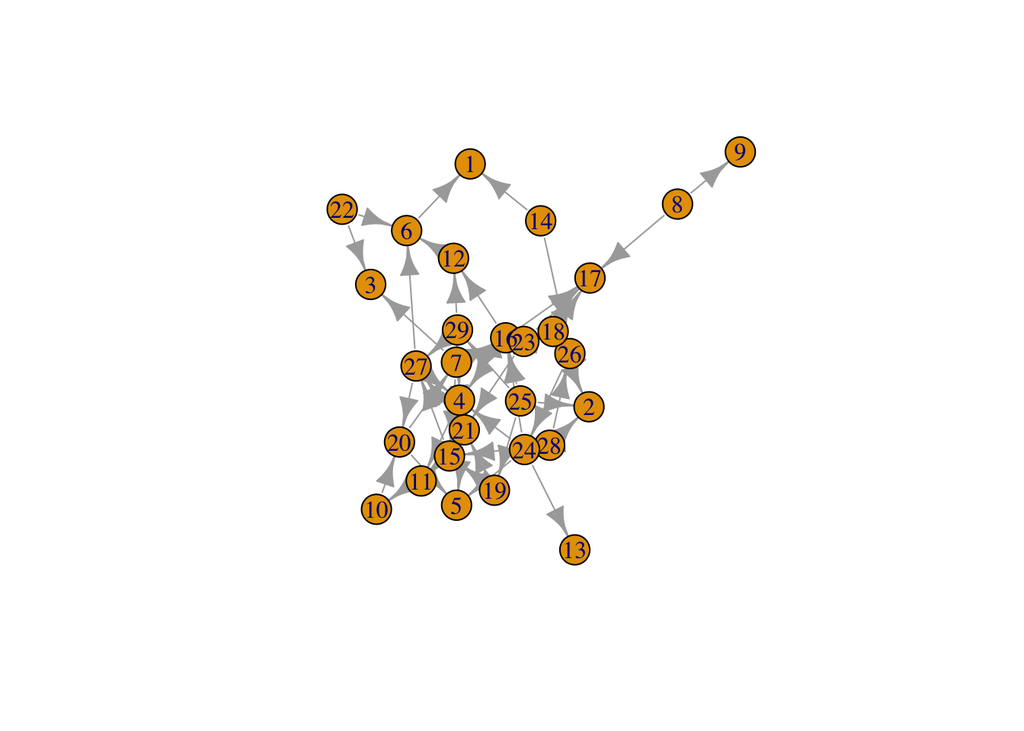

```r
#Load the igraph package

#install.packages("igraph", type = "binary")
library(igraph)
#First we will make an object that contains the graph information using our two dataframes EDGE and VERTEX. Notice that we have made "directed = TRUE" - our graph is directed since comments are being given from one student to another.

g <- graph.data.frame(EDGE, directed=TRUE, vertices=VERTEX)

#Now we can plot our graph using the force directed graphing technique - our old friend Fruchertman-Reingold!

plot(g,layout=layout.fruchterman.reingold)
```

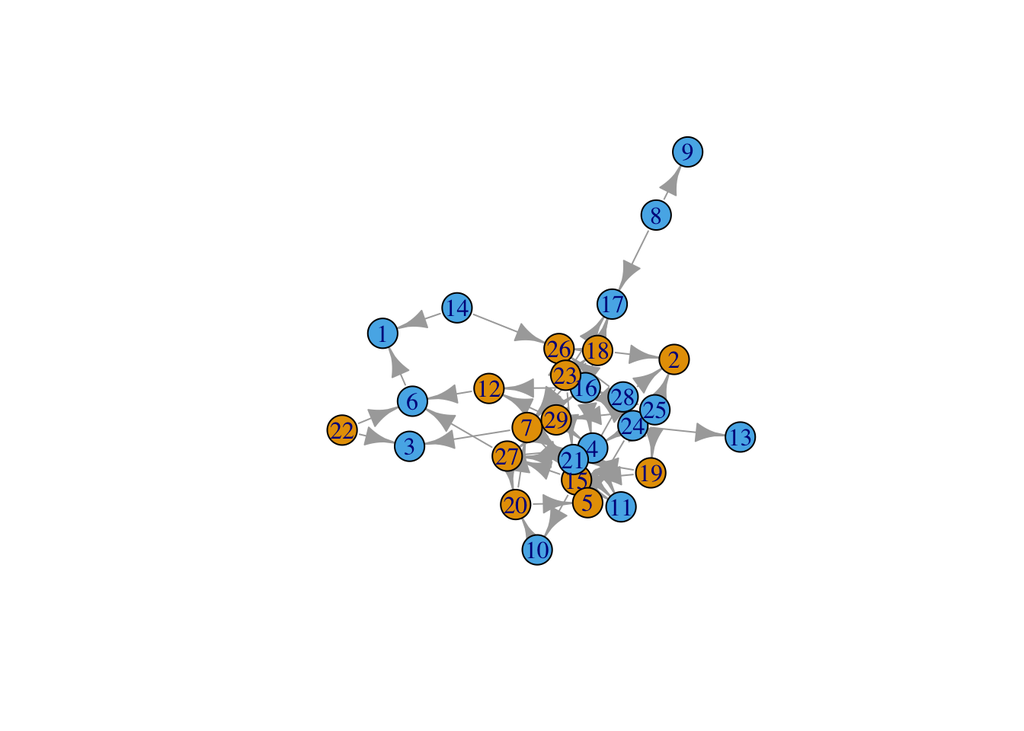

```r
#There are many ways to change the attributes of the graph to represent different characteristics of the newtork. For example, we can color the nodes according to gender.

plot(g,layout=layout.fruchterman.reingold, vertex.color=VERTEX$gender)
```

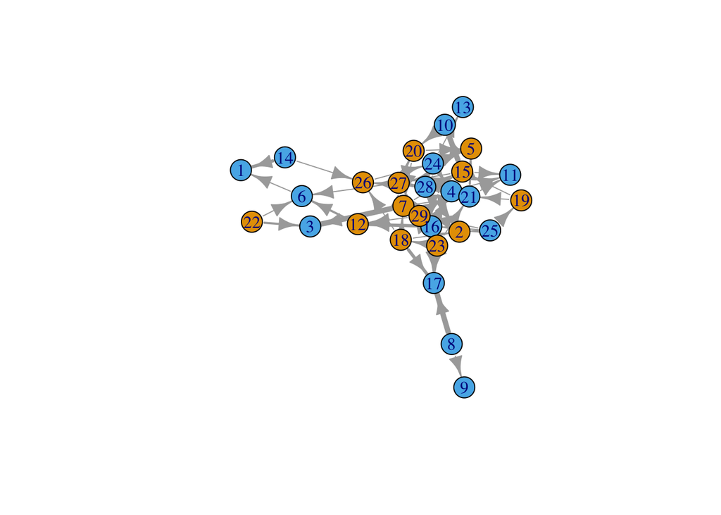

```r
#We can change the thickness of the edge according to the number of times a particular student has sent another student a comment.

plot(g,layout=layout.fruchterman.reingold, vertex.color=VERTEX$gender, edge.width=EDGE$count)
```

## Part II In Part II your task is to [look up](http://igraph.org/r/) in the igraph documentation and modify the graph above so that Ensure that sizing allows for an unobstructed view of the network features (For example, the arrow size is smaller). The vertices are colored according to major The vertices are sized according to the number of comments they have recieved

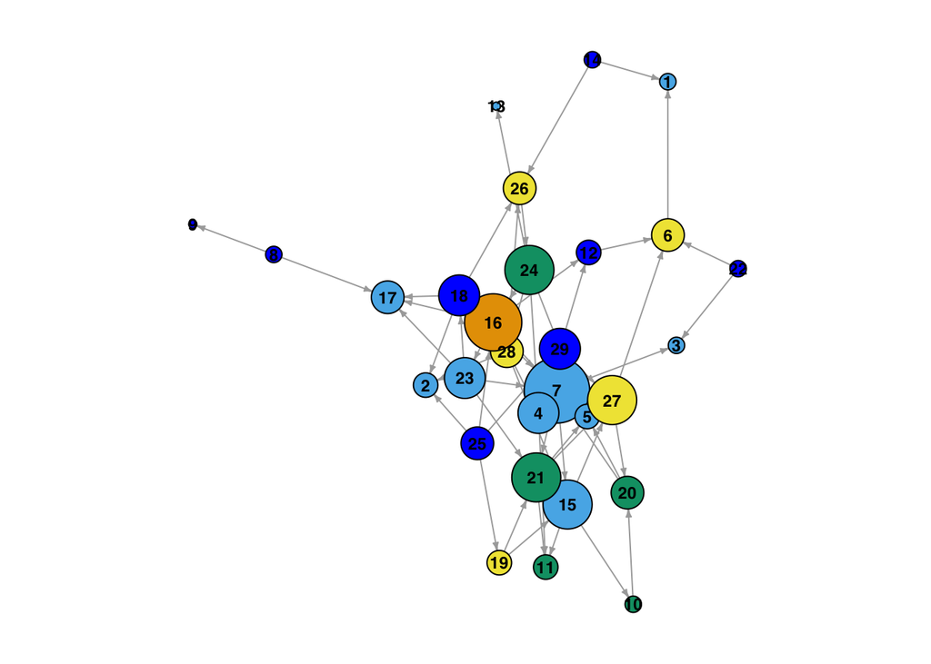

```r
# Graph 1: using fruchtermar.reingold

l <- layout.fruchterman.reingold(g, niter = 5000, area= vcount(g)^4*10) #for a more legible layout
par(mar=c(0,0,0,0)+.1) #to set the margin parameters

#color
V(g)$color <- 'blue' #default color
V(g)[EDGE$to]$color = VERTEX$major
#size
V(g)$vertex_degree <-  degree(g) # i used degree as a measure of how many points are connected to each vertex.

plot(g, layout= l,
     edge.arrow.size=0.3,
     vertex.label.cex=0.75,
     vertex.label.family="Helvetica",
     vertex.label.font=2,
     vertex.label.size = 8,
     vertex.shape="circle",
     vertex.size= V(g)$vertex_degree*3, # tomake it larger I added a *3 to my variable
     vertex.label.color= 'black')
```

## Part III

Now practice with data from our class. This data is real class data directly exported from Qualtrics and you will need to wrangle it into shape before you can work with it. Import it into R as a data frame and look at it carefully to identify problems.

Please create a **person-network** with the data set hudk4050-classes.csv. To create this network you will need to create a person-class matrix using the tidyr functions and then create a person-person matrix using `t()`. You will then need to plot a matrix rather than a to/from data frame using igraph.

Once you have done this, also [look up](http://igraph.org/r/) how to generate the following network metrics:

- Betweeness centrality and dregree centrality. **Who is the most central person in the network according to these two metrics? Write a sentence or two that describes your interpretation of these metrics**
- Color the nodes according to interest. Are there any clusters of interest that correspond to clusters in the network? Write a sentence or two describing your interpetation.

```r
library(tidyr)
library(dbplyr)
```

```r
library(stringr)
library(igraph)
library(readr)

#input data

C1 <- read.csv("hudk4050-classes.csv", stringsAsFactors = FALSE, header = TRUE) #for some reason
#the argument stringAsFactor made an error in my tidyr version
#copy to play
C2 <- C1
```

## Data Tyding

```r
#make header first row
colnames(C2) <- C2[1,]
#remove unwated rows
C2 <- slice(C2,3:49)
#remove last column
C2 <- select(C2, 1:8)
#Merge name columns
C2 <- unite(C2, "name", 'First Name', 'Last Name', sep = " " )
#Remove unpredictable characters from names
C2$name <- str_replace(C2$name, "'", "")
#Make all names capitalized frist letter only
C2$name <- str_to_title(C2$name)
#Make all class letters capital
C2 <- C2 %>% mutate_at(2:7, list(toupper)) #list is function in R
#Remove whitespace between  letters and number
C2 <- C2 %>% mutate_at(2:7, str_replace_all, " ", "")
```

## Data restructuring

```r
#Create a DF with two variables, student and class
C3 <- C2 %>% gather(label, class, 2:7, na.rm = TRUE, convert = TRUE) %>% select(name, class)
#Create a count variable
C3$count <-1
#Remove blank classes
C3  <- filter(C3, class != "")
#Remove duplicated
C3 <- unique(C3)
#Spread 1s across classes to create a student x class DF
C3 <- spread(C3, class, count)
#make row names student names
rownames(C3) <- C3$name
#Remove names column AND HUD4050
C3 <- select(C3, -name, -HUDK4050)
#shortest:
C3[is.na(C3)] <- 0
```

## Matrix operations

```r
#Convert to matrix
C4 <- as.matrix(C3)
#create person-person matrix
C4 <- C4 %*% t(C4)
```

## Graphing

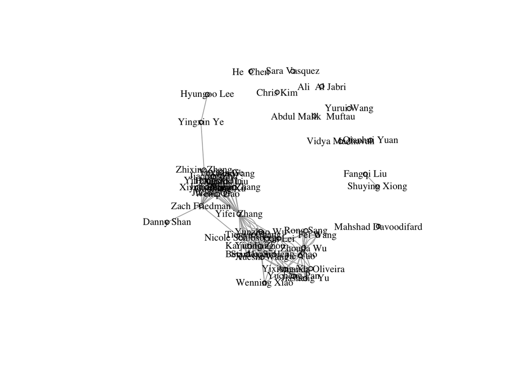

```r
g <- graph.adjacency(C4, mode= "undirected", diag = FALSE)

plot(g, layout=layout.fruchterman.reingold,
     vertex.size = 4,
     #degree(g)*07,
     vertex.label.cex = 0.8,
     vertex.label.color = "black",
     vertex.color = "gainsboro"
     )
```

## Centrality

```r
#Calculate the degree centrality of the nodes, showing who has the most connections
sort(degree(g), decreasing = T)
```

```
##          Guoliang Xu          Hangshi Jin           Jiaao ` Qi
##                   31                   31                   31
##          Jiacong Zhu          Jiahao Shen            Wenqi Gao
##                   31                   31                   31
##         Xiyun  Zhang          Yingxin Xie          Yifei Zhang
##                   31                   31                   24
##          Xiaojia Liu            Yuxuan Ge        Zhixin  Zheng
##                   22                   22                   20
## Stanley Si Heng Zhao              Dan Lei          Yuting Zhou
##                   19                   16                   16
##          Xueshi Wang            Zhouda Wu         Ruoyi  Zhang
##                   14                   14                   12
##         Tianyu Chang           Xijia Wang           Yunzhao Wu
##                   12                   12                   12
##              Jie Yao        Zach Friedman    Nicole Schlosberg
##                   11                   11                   10
##           Yixiong Xu           Berj Akian         Kaijie  Fang
##                   10                    9                    9
##            Rong Sang          Yucheng Pan      Amanda Oliveira
##                    8                    7                    6
##             Fei Wang          Jiasheng Yu         Wenning Xiao
##                    6                    6                    4
##           Yingxin Ye           Danny Shan           Fangqi Liu
##                    2                    1                    1
##          Hyungoo Lee        Shuying Xiong Abdul Malik  Muftau
##                    1                    1                    0
##        Ali  Al Jabri            Chris Kim             He  Chen
##                    0                    0                    0
##  Mahshad Davoodifard         Qianhui Yuan         Sara Vasquez
##                    0                    0                    0
##       Vidya Madhavan           Yurui Wang
##                    0                    0
```

##Betweeness

```r
#Calculate the betweeness centrality, showing how many 'shortest paths' pass through each node.
sort(betweenness(g), decreasing = T)
```

```
##          Yifei Zhang Stanley Si Heng Zhao              Dan Lei
##          260.6143603           97.2791152           83.4785714
##        Zhixin  Zheng        Zach Friedman    Nicole Schlosberg
##           66.2352941           43.3856397           36.6078619
##           Yingxin Ye          Xueshi Wang          Yuting Zhou
##           34.0000000           24.1453512           19.7898193
##            Zhouda Wu          Guoliang Xu          Hangshi Jin
##            8.9230159            7.5944061            7.5944061
##           Jiaao ` Qi          Jiacong Zhu          Jiahao Shen
##            7.5944061            7.5944061            7.5944061
##            Wenqi Gao         Xiyun  Zhang          Yingxin Xie
##            7.5944061            7.5944061            7.5944061
##           Yixiong Xu              Jie Yao          Xiaojia Liu
##            5.0523810            4.4984127            3.2007978
##            Yuxuan Ge          Yucheng Pan Abdul Malik  Muftau
##            3.2007978            0.8333333            0.0000000
##        Ali  Al Jabri      Amanda Oliveira           Berj Akian
##            0.0000000            0.0000000            0.0000000
##            Chris Kim           Danny Shan           Fangqi Liu
##            0.0000000            0.0000000            0.0000000
##             Fei Wang             He  Chen          Hyungoo Lee
##            0.0000000            0.0000000            0.0000000
##          Jiasheng Yu         Kaijie  Fang  Mahshad Davoodifard
##            0.0000000            0.0000000            0.0000000
##         Qianhui Yuan            Rong Sang         Ruoyi  Zhang
##            0.0000000            0.0000000            0.0000000
##         Sara Vasquez        Shuying Xiong         Tianyu Chang
##            0.0000000            0.0000000            0.0000000
##       Vidya Madhavan         Wenning Xiao           Xijia Wang
##            0.0000000            0.0000000            0.0000000
##           Yunzhao Wu           Yurui Wang
##            0.0000000            0.0000000
```

### To Submit Your Assignment

Please submit your assignment by first “knitting” your RMarkdown document into an html file and then comit, push and pull request both the RMarkdown file and the html file.